# Molecular Marker Assisted Plant Breeding

GBLUP and rrBLUP: two sides from the same coin

Felipe Ferrão

University of Florida

**Objectives:**

- 60 minutes of hands-on
- GBLUP and rrBLUP introduction
- Running simple examples in R

**Extra information**

- [HOS 6236 – Website](https://lfelipe-ferrao.github.io/class/mas/)
- About the [author](https://lfelipe-ferrao.github.io/)
- About the [UF/IFAS Plant Breeding](https://programs.ifas.ufl.edu/plant-breeding/)

# Introduction

In the past classes we addressed the use of Bayesian Alphabet, with particular focus on the use of different prior assumptions for the marker effects. Herein, we go back to the mixed model theory and frequentist framework and will discuss the ideas behind the use of GBLUP and RR-BLUP.

The **RR-BLUP (Ridge Regression Best Linear Unbiased Prediction)** and **GBLUP (Genomic Best Linear Unbiased Prediction)** are two of the most widely used statistical methods for predicting the genetic merit of individuals based on genomic information. Together, both methods form the foundation of modern genomic prediction, enabling more accurate and faster selection decisions, reducing generation intervals, and improving the overall efficiency of breeding programs.

# Theory

## General principles

Genomic selection refers to selection decisions based on genomic breeding values (GEBV). The GEBV can be computed using two equivalent models following these assumptions:

1. A model fitting individual SNP effects simultaneously. In this model, GEBV are computed as the sum of the effects of dense genetic markers, across the entire genome, thereby capturing all the quantitative trait loci that contribute to variation in a trait. This method can be referred as Ridge Regression, or SNP-BLUP or RR-BLUP. Relies on the genetic information based on **Marker-QTL LD**
2. A model estimating GEBV directly, by using mixed model equations and the covariance among breeding values defined by a genomic relationship matrices (G). Relies on the genetic information based on **Marker-Estimated Relationship**

## Ridge Regression

A traditional linear regression connecting phenotypes (y) and markers (X) can be written using the following notation:

$$y=\beta_0 + X\beta + e$$

where the error is normally distributed as: $e\sim N(0,\sigma)$

Traditional linear regression models seek to mimimize the squared error between predicted and actual observations.

$$argmin_\beta\ \sum^n_{i=1} (y_i -
\beta_0 -\sum^p_{j=1} \beta_jx_{ij})^2$$

Ridge regression aim to estimate more conservative values for the $\beta$ weights in a model, and this is true for both frequentist and Bayesian versions of regularization. The extention from traditional to Ridge Regression is made by modifying the loss function (first term of the equation) to include a penalty term for model complexity (second term):

$$argmin_\beta\ \sum^n_{i=1} (y_i -
\beta_0 -\sum^p_{j=1} \beta_jx_{ij})^2 + \lambda
\sum^p_{j=1}\beta^2_j$$
Or in a matrix notation:

$$\hat{\beta} = (X'X + \lambda
I)^{-1}X'y$$

The second term in the Ridge Regression formula is called **shrinkage penalty** and is responsible for the regularization. The central question is deciding how stringent the regularization process should be. As the penalty grows, the degree of shrinkage becomes stronger, and eventually all of the $\beta$ (i.e., marker effects) are shrunk to zero. A model with all regression coefficients close to null values is not desirable, as it does have any power to prediction. However, when this is close to the null value, the penalty term has no effect, and Ridge Regression will produce the least square estimates. Hence, an ideal scheme is one that can selectively shrink the regression coefficients; i.e., markers with small or no effects should be severely penalized, whereas those with larger effects should not be shrunk at all.

The penalty function, in the RR-BLUP, has a specific form and can be represented as: $\lambda = 2 \sum p_i (1-p_i) \times \frac{\sigma^2_e}{\sigma^2_a}$, where p is the allele frequency.

Below we presented a simple representation of RR-BLUP method.

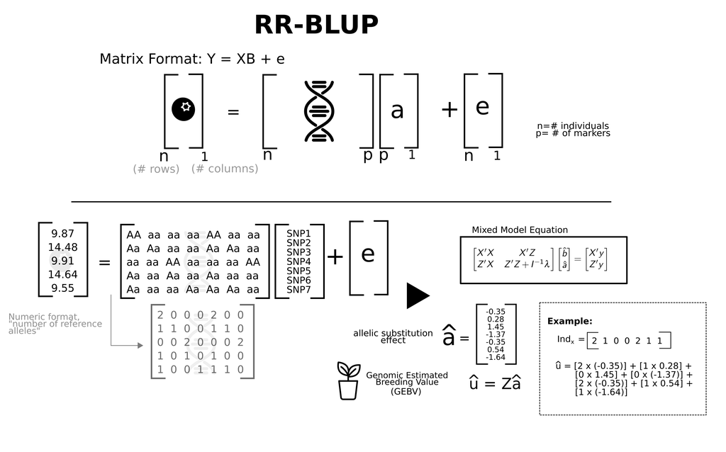

## GBLUP

Genetic markers across the entire genome can be used to measure genetic similarities. Markers estimate proportion of chromosome segments shared by individuals including identification of genes identical by state (IBS). More details about the GBLUP is presented in this [link](https://htmlpreview.github.io/?https://github.com/lfelipe-ferrao/lfelipe-ferrao.github.io/blob/master/class/quantGenetic/week12.html).

Bellow the equation system that need to be solved to compute the GEBV:

$$\begin{bmatrix} {X'R^{-1}X} & {X'R^{-1}Z} \\ {Z'R^{-1}X}
& {Z'R^{-1}Z} + {G^{-1}\lambda} \end{bmatrix}
\begin{bmatrix} {\hat{b}}\\ {\hat{u}} \end{bmatrix}
=
\begin{bmatrix} {X'R^{-1}y} \\ {Z'R^{-1}y} \end{bmatrix}$$

$$\hat{b} =
(X'V^{-1}X)^{-1}XV^{-1}y$$

$$\hat{u} =
GZ'V^{-1}(y-X\hat{b})$$

Where the genomic relationship matrix can be computed using:

$$G= \dfrac{ZZ'}{2 \sum p_i (1-p_i)}
= \dfrac{(M-P)(M-P)'}{2 \sum^m_{j=1} p_j (1-p_j)}$$

Below we presented a simple representation of GBLUP method. When compared to the previus RR-BLUP representation,instead of treating marker as predictors, can predict additive values directly as multivariate normal effects. In this case, the markers are used to compute a covariance matrix that is proportional to genomic relationship matrix **G**.

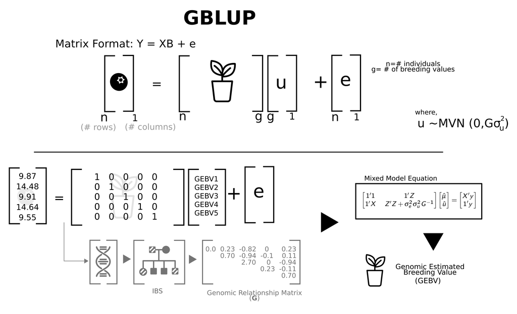

## GBLUP and RR-BLUP are equivalent models

BLUP and RR-BLUP are equivalent models, as presented below:

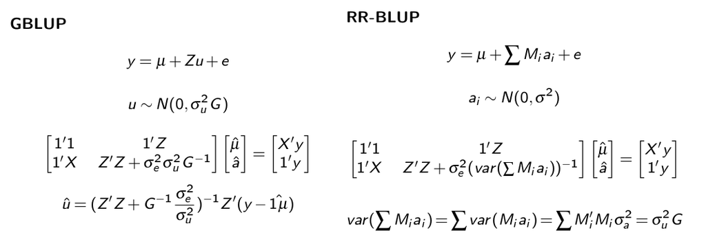

The use of GBLUP model has some important features that make it widely used in GS:

- GEBVs can be calculated in the same way as in pedigree-based BLUP, using software and concepts well known in breeding routines
- In contrast with the penalized regression (RR and LASSO), the dimensions of the genetic effects are reduced from p × p (where p is the number of markers) to n × n (where n is the number of individuals), which is more efficient for computing purposes.
- More complex models incorporating GxE interactions and multi-trait analysis can be easily included
- Pedigree and genomic data can be incorporated in the s0-called single step BLUPs

# Hands-on

## Wheat data set

- We will use two packages:
  - `rrBLUP`: to fit the Ridge Regression and GBLUP models
  - `BGLR`: to download the data
- Wheat data imported from the `BGLR` package
- From the `rrBLUP` we will compute the marker effects and the genomic relationship matrix to compute the `GBLUP` models.

**RR-BLUP**

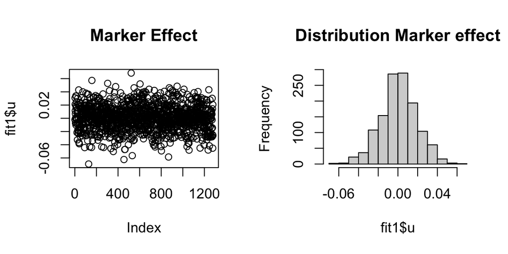

```r
library(BGLR)
library(rrBLUP)

# Download the data
data(wheat)

# Fit RRBLUP for the environment 1
fit1 <- mixed.solve(y = wheat.Y[,1],
                    Z = wheat.X) # Estimating marker effects

# Ploting the marker effects
par(mfrow=c(1,2))
plot(fit1$u,main="Marker Effect")
hist(fit1$u, main = "Distribution Marker effect")
```

```r
# To compute the GEBV, I just need to multiple the SNP effect by the genotype
gebv = wheat.X %*% fit1$u # GEBV
```

**GBLUP**

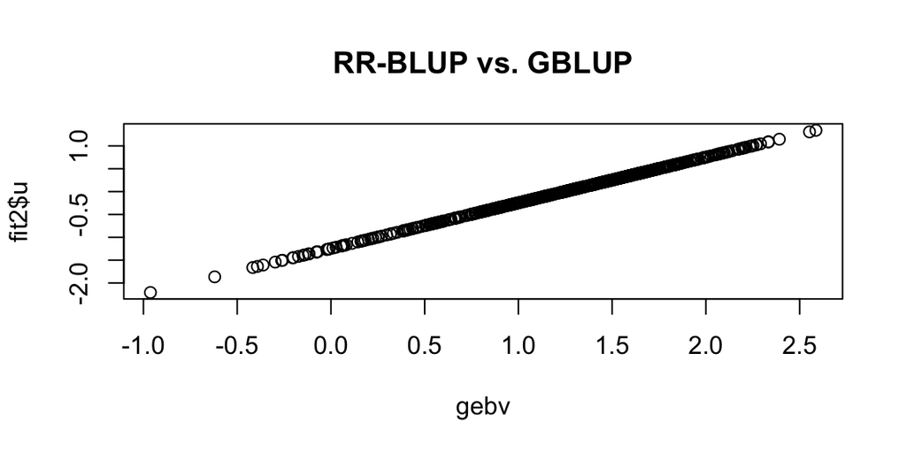

```r
# Fit GBLUP
G =A.mat(wheat.X) # Computing the G matrix
fit2 <- mixed.solve(y = wheat.Y[,1], K = G) # Fit GBLUP
#fit2$Vu/(fit2$Ve+fit2$Vu) # h2
plot(gebv, fit2$u, main = "RR-BLUP vs. GBLUP")
```

# Final comments

# References

- Endelman, J.B. (2011). Ridge regression and other kernels for genomic selection with R package rrBLUP. The Plant Genome, 4:250–255. doi:10.3835/plantgenome2011.08.0024.
- Endelman, J.B. & Jannink, J.-L. (2012). Shrinkage estimation of the realized relationship matrix. G3: Genes, Genomes, Genetics, 2:1405–1413. doi:10.1534/g3.112.004259
- Van Raden, P.M. (2008). Efficient methods to compute genomic predictions. Journal of Dairy Science, 91:4414–4423. doi:10.3168/jds.2007-0980.

[figure not shown]